# LASSO, RIDGE Y ELASTICNET

JGB1970

2022-08-31

```r
library(dplyr)
library(tidyr)
library(ggplot2)
library(performance)
library(moments)
library(RColorBrewer)
library(fastDummies)
library(glmnet)
library(ISLR)
library(recipes)
library(rsample)
library(glmnetUtils)
library(caret)
library(openxlsx)
library(writexl)
library(corrplot)
library(car)
library(olsrr)
library(GGally)
library(MASS)
library(tseries)
library(naniar)
library(ggpubr)
library(broom)
library(lmtest)
library(leaps)
library(recipes)
select <- dplyr::select
library(circlize)
library(FactoMineR)
library(factoextra)
```

#APLICACION LASSO, RIDGE Y ELASTICNET SOBRE EL DATASET

```r
df <- read.csv("C:\\Users\\JULIAN\\Desktop\\CLASES DE R\\EJERCICIOS CLASE\\clases\\data\\kc_house_data.csv")
df <- df %>% select(everything(), -id,-date)
df$bathrooms <-  as.integer(df$bathrooms)
df$floors <-  as.integer(df$floors)
```

**Utilizaré las técnicas de regularización Lasso, Ridge y Elasticnet. Estas técnicas reducen el número de predictores: en el caso de Ridge, asignándoles betas pequeños, Lasso saca las variables del modelo directamente. Elasticnet es una mezcla de los anteriores procedimientos.**

Para aplicarlas dividimos el dataframe en dos partes, test y training (90%). La idea es preprocesar los datos mediante el objeto recipe (hacer transformaciones BoxCox, variables dummy, edición de determinadas columnas, búsqueda de NAs, recipe tiene una gran cantidad de funciones para aplicar al dataset…) trabajando sobre los datos de train. Mediante prep(), realizamos todos los cálculos necesarios para satisfacer los requerimientos de recipe (por ejemplo,calcular medias y desviaciones para centrar y escalar mediante step_normalize). Con bake() realizamos los pasos del preprocesamiento sobre los datasets, tanto train como test, para que las estructuras sean semejantes.

```r
set.seed(1234)
train_test_split <- initial_split(df, 0.9)
train <- training(train_test_split)
test <- testing(train_test_split)
```

Modifico la clase de estas variables, para convertirlas en nominales y obtener dummies en el recipe.

```r
train <- train %>% mutate(
  grade = as.factor(grade),
  zipcode = as.factor(zipcode),
  condition = as.factor(condition),
  waterfront = as.factor(waterfront))
```

Inicializamos el objeto recipe indicando la variable dependiente y el dataset.

```r
rec_obj <- recipe(price ~ ., data = train)
```

En esta parte del código, transformo las variables nominales en dummies. No normalizo, ni hago BoxCox, para poder comparar en las predicciones entre estos modelos y los creados en aprtados anteriores. (RMSE)

```r
rec_obj <- rec_obj %>%
  step_dummy(all_nominal())



#rec_obj <- rec_obj %>%
  #step_normalize(all_numeric(), - price)

#rec_obj <- rec_obj %>%
 # step_BoxCox(price)


trained_rec <- prep(rec_obj, training = train)
```

Aplico a los datasets train and test los pasos diseñados en el recipe.

```r
train_data <- bake(trained_rec, new_data = train)
test_data  <- bake(trained_rec, new_data = test)
```

Aquí comparo las estructuras generadas con el bake(). Me queda la duda de saber si tendría que haber realizado la conversión a factores en el dataset original, antes de dividir en test y train, ya que en el caso de la variable grade hay un único registro con el valor 1: si dicho valor cae inicialmente en el set de test, ¿cómo puede generar la columna dummy apropiada el logaritmo en el recipe de train? En los ejercicios de clase, veo que se comparan las estructuras de los datasets, aquí me salen idénticas. (grade = 1 cae en train)

```r
testi <- test[test$grade==1,]
traini <- train[train$grade==1,]
testi
```

| price | bedrooms | bathrooms | sqft_living | sqft_lot | floors | waterfront | view | condition | grade | sqft_above | sqft_basement | yr_built | yr_renovated | zipcode | lat | long | sqft_living15 | sqft_lot15 |
| --- | --- | --- | --- | --- | --- | --- | --- | --- | --- | --- | --- | --- | --- | --- | --- | --- | --- | --- |

```r
traini
```

|  | price | bedrooms | bathrooms | sqft_living | sqft_lot | floors | waterfront | view | condition | grade | sqft_above | sqft_basement | yr_built | yr_renovated | zipcode | lat | long | sqft_living15 | sqft_lot15 |
| --- | --- | --- | --- | --- | --- | --- | --- | --- | --- | --- | --- | --- | --- | --- | --- | --- | --- | --- | --- |
| 19453 | 142000 | 0 | 0 | 290 | 20875 | 1 | 0 | 0 | 1 | 1 | 290 | 0 | 1963 | 0 | 98024 | 47.5308 | -121.888 | 1620 | 22850 |

```r
colnames(train_data)
```

```
##   [1] "bedrooms"       "bathrooms"      "sqft_living"    "sqft_lot"
##   [5] "floors"         "view"           "sqft_above"     "sqft_basement"
##   [9] "yr_built"       "yr_renovated"   "lat"            "long"
##  [13] "sqft_living15"  "sqft_lot15"     "price"          "waterfront_X1"
##  [17] "condition_X2"   "condition_X3"   "condition_X4"   "condition_X5"
##  [21] "grade_X3"       "grade_X4"       "grade_X5"       "grade_X6"
##  [25] "grade_X7"       "grade_X8"       "grade_X9"       "grade_X10"
##  [29] "grade_X11"      "grade_X12"      "grade_X13"      "zipcode_X98002"
##  [33] "zipcode_X98003" "zipcode_X98004" "zipcode_X98005" "zipcode_X98006"
##  [37] "zipcode_X98007" "zipcode_X98008" "zipcode_X98010" "zipcode_X98011"
##  [41] "zipcode_X98014" "zipcode_X98019" "zipcode_X98022" "zipcode_X98023"
##  [45] "zipcode_X98024" "zipcode_X98027" "zipcode_X98028" "zipcode_X98029"
##  [49] "zipcode_X98030" "zipcode_X98031" "zipcode_X98032" "zipcode_X98033"
##  [53] "zipcode_X98034" "zipcode_X98038" "zipcode_X98039" "zipcode_X98040"
##  [57] "zipcode_X98042" "zipcode_X98045" "zipcode_X98052" "zipcode_X98053"
##  [61] "zipcode_X98055" "zipcode_X98056" "zipcode_X98058" "zipcode_X98059"
##  [65] "zipcode_X98065" "zipcode_X98070" "zipcode_X98072" "zipcode_X98074"
##  [69] "zipcode_X98075" "zipcode_X98077" "zipcode_X98092" "zipcode_X98102"
##  [73] "zipcode_X98103" "zipcode_X98105" "zipcode_X98106" "zipcode_X98107"
##  [77] "zipcode_X98108" "zipcode_X98109" "zipcode_X98112" "zipcode_X98115"
##  [81] "zipcode_X98116" "zipcode_X98117" "zipcode_X98118" "zipcode_X98119"
##  [85] "zipcode_X98122" "zipcode_X98125" "zipcode_X98126" "zipcode_X98133"
##  [89] "zipcode_X98136" "zipcode_X98144" "zipcode_X98146" "zipcode_X98148"
##  [93] "zipcode_X98155" "zipcode_X98166" "zipcode_X98168" "zipcode_X98177"
##  [97] "zipcode_X98178" "zipcode_X98188" "zipcode_X98198" "zipcode_X98199"
```

```r
colnames(test_data)
```

```
##   [1] "bedrooms"       "bathrooms"      "sqft_living"    "sqft_lot"
##   [5] "floors"         "view"           "sqft_above"     "sqft_basement"
##   [9] "yr_built"       "yr_renovated"   "lat"            "long"
##  [13] "sqft_living15"  "sqft_lot15"     "price"          "waterfront_X1"
##  [17] "condition_X2"   "condition_X3"   "condition_X4"   "condition_X5"
##  [21] "grade_X3"       "grade_X4"       "grade_X5"       "grade_X6"
##  [25] "grade_X7"       "grade_X8"       "grade_X9"       "grade_X10"
##  [29] "grade_X11"      "grade_X12"      "grade_X13"      "zipcode_X98002"
##  [33] "zipcode_X98003" "zipcode_X98004" "zipcode_X98005" "zipcode_X98006"
##  [37] "zipcode_X98007" "zipcode_X98008" "zipcode_X98010" "zipcode_X98011"
##  [41] "zipcode_X98014" "zipcode_X98019" "zipcode_X98022" "zipcode_X98023"
##  [45] "zipcode_X98024" "zipcode_X98027" "zipcode_X98028" "zipcode_X98029"
##  [49] "zipcode_X98030" "zipcode_X98031" "zipcode_X98032" "zipcode_X98033"
##  [53] "zipcode_X98034" "zipcode_X98038" "zipcode_X98039" "zipcode_X98040"
##  [57] "zipcode_X98042" "zipcode_X98045" "zipcode_X98052" "zipcode_X98053"
##  [61] "zipcode_X98055" "zipcode_X98056" "zipcode_X98058" "zipcode_X98059"
##  [65] "zipcode_X98065" "zipcode_X98070" "zipcode_X98072" "zipcode_X98074"
##  [69] "zipcode_X98075" "zipcode_X98077" "zipcode_X98092" "zipcode_X98102"
##  [73] "zipcode_X98103" "zipcode_X98105" "zipcode_X98106" "zipcode_X98107"
##  [77] "zipcode_X98108" "zipcode_X98109" "zipcode_X98112" "zipcode_X98115"
##  [81] "zipcode_X98116" "zipcode_X98117" "zipcode_X98118" "zipcode_X98119"
##  [85] "zipcode_X98122" "zipcode_X98125" "zipcode_X98126" "zipcode_X98133"
##  [89] "zipcode_X98136" "zipcode_X98144" "zipcode_X98146" "zipcode_X98148"
##  [93] "zipcode_X98155" "zipcode_X98166" "zipcode_X98168" "zipcode_X98177"
##  [97] "zipcode_X98178" "zipcode_X98188" "zipcode_X98198" "zipcode_X98199"
```

En este paso creo una matriz a partir del dataframe (lo exige la función) con las columnas predictoras y extraigo el valor de la dependiente. El valor de alpha especifica el modelo a utilizar entre los tres posibles. Genero los modelos.

```r
x_train <- train_data %>%
  select(-price) %>%
  as.data.frame()
y_train <- train_data %>% pull(price)



fit.lasso.cv <- cv.glmnet(x_train %>% as.matrix(), y_train, type.measure="mse", alpha=1, family="gaussian", nfolds = 30)
fit.ridge.cv <- cv.glmnet(x_train%>% as.matrix(), y_train, type.measure="mse", alpha=0,family="gaussian", nfolds = 30)
fit.elnet.cv <- cv.glmnet(x_train%>% as.matrix(), y_train, type.measure="mse", alpha = 0.5, family="gaussian", nfolds = 30)
```

Obtenemos los coeficientes de la regresión lineal a partir del lambda mínimo que optimiza cada modelo.

```r
coef(fit.elnet.cv, s = "lambda.min")
```

```
## 100 x 1 sparse Matrix of class "dgCMatrix"
##                           s1
## (Intercept)    -3.045936e+07
## bedrooms       -1.105151e+04
## bathrooms       2.577599e+04
## sqft_living     1.111772e+02
## sqft_lot        2.303945e-01
## floors         -2.859043e+04
## view            5.139588e+04
## sqft_above      4.845595e+01
## sqft_basement   .
## yr_built       -1.739885e+02
## yr_renovated    2.472957e+01
## lat             4.732018e+05
## long           -6.873180e+04
## sqft_living15   2.025637e+01
## sqft_lot15     -1.198778e-01
## waterfront_X1   6.319673e+05
## condition_X2   -8.216729e+03
## condition_X3    .
## condition_X4    2.716216e+04
## condition_X5    7.206930e+04
## grade_X3        6.101255e+04
## grade_X4        2.720257e+04
## grade_X5       -3.128559e+04
## grade_X6       -2.967350e+04
## grade_X7       -2.349431e+04
## grade_X8        .
## grade_X9        7.595962e+04
## grade_X10       1.979303e+05
## grade_X11       3.846762e+05
## grade_X12       8.093698e+05
## grade_X13       1.573783e+06
## zipcode_X98002 -3.350105e+03
## zipcode_X98003 -2.235372e+04
## zipcode_X98004  5.978740e+05
## zipcode_X98005  1.521024e+05
## zipcode_X98006  1.252496e+05
## zipcode_X98007  1.080723e+05
## zipcode_X98008  1.206764e+05
```

[output cut: 47 more lines]

```
## zipcode_X98125 -1.465288e+03
## zipcode_X98126  6.109105e+04
## zipcode_X98133 -5.228629e+04
## zipcode_X98136  1.267456e+05
## zipcode_X98144  1.347546e+05
## zipcode_X98146 -8.047782e+03
## zipcode_X98148  .
## zipcode_X98155 -7.575953e+04
## zipcode_X98166 -2.932109e+04
## zipcode_X98168 -4.564454e+04
## zipcode_X98177 -3.108795e+03
## zipcode_X98178 -6.823850e+04
## zipcode_X98188 -4.160048e+04
## zipcode_X98198 -5.451788e+04
## zipcode_X98199  2.093560e+05
```

```r
coef(fit.lasso.cv, s = "lambda.min")
```

```
## 100 x 1 sparse Matrix of class "dgCMatrix"
##                           s1
## (Intercept)    -3.033727e+07
## bedrooms       -1.109530e+04
## bathrooms       2.568724e+04
## sqft_living     1.113896e+02
## sqft_lot        2.305766e-01
## floors         -2.864721e+04
## view            5.138495e+04
## sqft_above      4.839570e+01
## sqft_basement   .
## yr_built       -1.711717e+02
## yr_renovated    2.474785e+01
## lat             4.726430e+05
## long           -6.789979e+04
## sqft_living15   2.014300e+01
## sqft_lot15     -1.204252e-01
## waterfront_X1   6.322526e+05
## condition_X2   -8.194405e+03
## condition_X3    .
## condition_X4    2.715544e+04
## condition_X5    7.208305e+04
## grade_X3        6.098989e+04
## grade_X4        2.745176e+04
## grade_X5       -3.110403e+04
## grade_X6       -2.952650e+04
## grade_X7       -2.342079e+04
## grade_X8        .
## grade_X9        7.600318e+04
## grade_X10       1.979842e+05
## grade_X11       3.847790e+05
## grade_X12       8.095403e+05
## grade_X13       1.574147e+06
## zipcode_X98002 -2.670562e+03
## zipcode_X98003 -2.156616e+04
## zipcode_X98004  5.990423e+05
## zipcode_X98005  1.530503e+05
## zipcode_X98006  1.261080e+05
## zipcode_X98007  1.089825e+05
## zipcode_X98008  1.215382e+05
```

[output cut: 47 more lines]

```
## zipcode_X98125 -4.619517e+02
## zipcode_X98126  6.208466e+04
## zipcode_X98133 -5.126099e+04
## zipcode_X98136  1.278090e+05
## zipcode_X98144  1.357812e+05
## zipcode_X98146 -7.150208e+03
## zipcode_X98148  .
## zipcode_X98155 -7.477507e+04
## zipcode_X98166 -2.845990e+04
## zipcode_X98168 -4.482117e+04
## zipcode_X98177 -2.020360e+03
## zipcode_X98178 -6.746227e+04
## zipcode_X98188 -4.081042e+04
## zipcode_X98198 -5.373837e+04
## zipcode_X98199  2.105198e+05
```

```r
coef(fit.ridge.cv, s = "lambda.min")
```

```
## 100 x 1 sparse Matrix of class "dgCMatrix"
##                           s1
## (Intercept)    -3.069851e+07
## bedrooms       -7.983437e+03
## bathrooms       3.025882e+04
## sqft_living     7.000124e+01
## sqft_lot        2.161711e-01
## floors         -1.646322e+04
## view            5.041401e+04
## sqft_above      7.434315e+01
## sqft_basement   3.845495e+01
## yr_built       -3.579693e+02
## yr_renovated    2.442874e+01
## lat             4.142012e+05
## long           -9.711517e+04
## sqft_living15   3.117699e+01
## sqft_lot15     -1.059672e-01
## waterfront_X1   5.957000e+05
## condition_X2   -2.883291e+04
## condition_X3   -1.602981e+04
## condition_X4    1.017913e+04
## condition_X5    5.255546e+04
## grade_X3        4.677707e+04
## grade_X4       -4.002650e+03
## grade_X5       -6.341241e+04
## grade_X6       -5.783904e+04
## grade_X7       -5.171091e+04
## grade_X8       -2.787778e+04
## grade_X9        4.706094e+04
## grade_X10       1.656951e+05
## grade_X11       3.463698e+05
## grade_X12       7.557284e+05
## grade_X13       1.490068e+06
## zipcode_X98002 -5.747435e+04
## zipcode_X98003 -7.870470e+04
## zipcode_X98004  5.244539e+05
## zipcode_X98005  1.072826e+05
## zipcode_X98006  7.941618e+04
## zipcode_X98007  6.523482e+04
## zipcode_X98008  8.015177e+04
```

[output cut: 47 more lines]

```
## zipcode_X98125 -3.860291e+04
## zipcode_X98126  1.105841e+04
## zipcode_X98133 -8.631315e+04
## zipcode_X98136  6.999939e+04
## zipcode_X98144  8.041289e+04
## zipcode_X98146 -5.579147e+04
## zipcode_X98148 -5.157180e+04
## zipcode_X98155 -1.044779e+05
## zipcode_X98166 -7.602945e+04
## zipcode_X98168 -9.184247e+04
## zipcode_X98177 -3.937013e+04
## zipcode_X98178 -1.107300e+05
## zipcode_X98188 -8.913680e+04
## zipcode_X98198 -1.028245e+05
## zipcode_X98199  1.528080e+05
```

Esta función nos proporcionará, como en casos anteriores el RMSE y el R de cada modelo.

```r
eval_results <- function(true, predicted, df) {
  SSE <- sum((predicted - true)^2)
  SST <- sum((true - mean(true))^2)
  R_square <- 1 - SSE / SST
  RMSE = sqrt(SSE/nrow(df))


data.frame(
    RMSE = RMSE,
    Rsquare = R_square
  )
}
```

Preparo las predictoras del test_data, el test que hemos pasado por el bake() y saco la variable price, para las predicciones posteriores.

```r
x_test <- test_data %>%
  select(-price) %>%
  as.data.frame()

y_test <- test_data %>% pull(price)
```

Introduzco en variables que utilizaré luego los lambdas minimos para cada modelo.

```r
lambda_elnet_best <- fit.elnet.cv$lambda.min
lambda_lasso_best <-  fit.lasso.cv$lambda.min
lambda_ridge_best <- fit.ridge.cv$lambda.min
```

Genero las predicciones y evalúo el RMSE y la R para cada una de las técnicas, en el test y el train.

MODELO LASSO.  
Lasso: Predicción y evaluación sobre train.

```r
predictions_train <- predict(fit.lasso.cv, s = lambda_lasso_best, newx = x_train%>% as.matrix())
eval_results(y_train, predictions_train, x_train%>% as.matrix())
```

| RMSE | Rsquare |
| --- | --- |
| 147707.9 | 0.8363887 |

Lasso: Predicción y evaluación sobre test.

```r
predictions_test_la <- predict(fit.lasso.cv, s = lambda_lasso_best, newx = x_test%>% as.matrix())
eval_results(y_test, predictions_test_la, test_data)
```

| RMSE | Rsquare |
| --- | --- |
| 164787 | 0.8158586 |

```r
#voy creando este dataframe para generar gráficos
graf_lasso <- data.frame(y_test, predictions_test_la)
graf_lasso$modelo <- "LASSO"
```

MODELO RIDGE.  
Ridge: Predicción y evaluación sobre train.

```r
predictions_train <- predict(fit.ridge.cv, s = lambda_ridge_best, newx = x_train%>% as.matrix())
eval_results(y_train, predictions_train, x_train%>% as.matrix())
```

| RMSE | Rsquare |
| --- | --- |
| 148548.1 | 0.834522 |

Ridge: Predicción y evaluación sobre test.

```r
predictions_test_ri <- predict(fit.ridge.cv, s = lambda_ridge_best, newx = x_test%>% as.matrix())
eval_results(y_test, predictions_test_ri,test_data)
```

| RMSE | Rsquare |
| --- | --- |
| 167174.5 | 0.8104841 |

```r
#voy creando este dataframe para generar gráficos
graf_ridge <- data.frame(y_test, predictions_test_ri)
graf_ridge$modelo <- "RIDGE"
```

MODELO ELASTICNET.  
Elasticnet: Predicción y evaluación sobre train.

```r
predictions_train <- predict(fit.elnet.cv, s = lambda_elnet_best, newx = x_train%>% as.matrix())
eval_results(y_train, predictions_train, x_train%>% as.matrix())
```

| RMSE | Rsquare |
| --- | --- |
| 147709.5 | 0.8363852 |

Elasticnet: Predicción y evaluación sobre test.

```r
predictions_test_el <- predict(fit.elnet.cv, s = lambda_elnet_best, newx = x_test%>% as.matrix())
eval_results(y_test, predictions_test_el,test_data)
```

| RMSE | Rsquare |
| --- | --- |
| 164804.9 | 0.8158186 |

```r
#voy creando este dataframe para generar gráficos
graf_elastic <- data.frame(y_test, predictions_test_el)
graf_elastic$modelo <- "ELASTIC"
```

En este caso, el mejor modelo sería Lasso, presenta un menor RMSE (también mejor R).

Grafico valores reales contra predichos. Aunque los tres gráficos parecen iguales, se pueden constatar pequeñas diferencias entre los valores portados por cada modelo

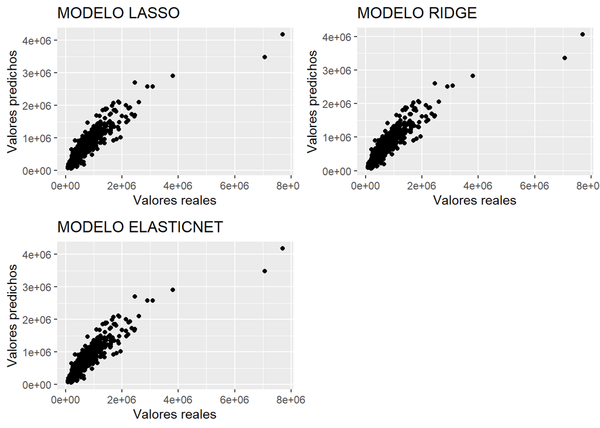

```r
lass  <-  ggplot(data = graf_lasso, aes(x = y_test, y= s1 ))+
  geom_point() +labs(title= "MODELO LASSO", x="Valores reales", y = "Valores predichos")


rid <- ggplot(data = graf_ridge, aes(x = y_test, y= s1 ))+
  geom_point() +labs(title= "MODELO RIDGE", x="Valores reales", y = "Valores predichos")


elas <- ggplot(data = graf_elastic, aes(x = y_test, y= s1 ))+
  geom_point() + labs(title= "MODELO ELASTICNET", x="Valores reales", y = "Valores predichos")

lista <- list(lass, rid, elas)

ggarrange(plotlist=lista,  ncol = 2, nrow = 2)
```

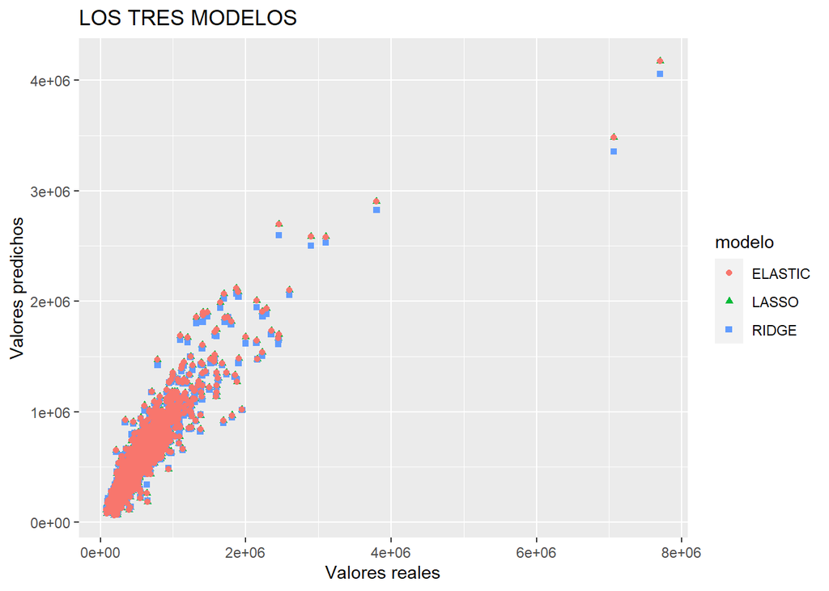

```r
grafico <- rbind(graf_lasso, graf_ridge, graf_elastic)
grafico %>% ggplot(aes(x = y_test, y= s1, color = modelo, shape = modelo ))+
  geom_point() + labs(title= "LOS TRES MODELOS", x="Valores reales", y = "Valores predichos")
```